# 動物實驗設計與研究方法

Week 10｜動物研究開始前的規劃：PREPARE

陳敬元 Jing-Yuan Chen, DVM, PhD

jychen@niar.org.tw

國家實驗研究院國家生物模式中心

宜蘭大學生物技術與動物科學系

# 01｜實驗開始前…

- 認識 PREPARE：研究開始前，要先想清楚哪些事。
- 知道本週從 15 項裡，挑了哪幾項來講。
- 用真實研究的例子，理解這些項目為什麼重要。

## 本週案例：一篇 2020 年的小鼠研究

[figure not shown]

實驗小鼠的腸道菌相，因時間與生產房間改變，影響實驗能否重現。

[Mandal et al. 2020，BMC Biology 18:83](https://doi.org/10.1186/s12915-020-00810-7) · [CC BY 4.0](https://creativecommons.org/licenses/by/4.0/)

## 起因：同一個生產室，2017 年起瘧疾變嚴重

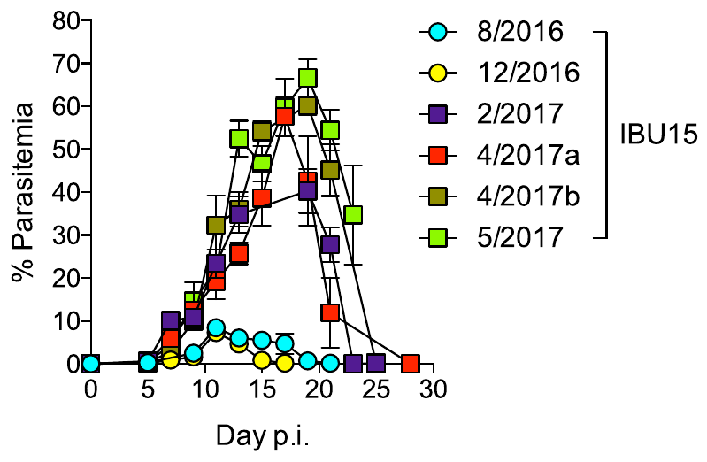

- 作者固定只向同一個生產室 (IBU15) 訂購小鼠
- 2017 年起感染明顯變嚴重。

改自 [Mandal et al. 2020，Fig. 1A、p. 2](https://doi.org/10.1186/s12915-020-00810-7) · [CC BY 4.0](https://creativecommons.org/licenses/by/4.0/)

## PREPARE 的用途

[figure not shown]

- 規劃研究與協調執行條件
- 依研究、物種與場域選擇適用事項
- 清單搭配官方網站的主題說明

本週用它討論 **研究開始前需要共同準備的條件**。

[Smith et al. 2018](https://doi.org/10.1177/0023677217724823)

## PREPARE 的三個範圍

[figure not shown]

[Smith et al. 2018，Table 1](https://doi.org/10.1177/0023677217724823) · [CC BY-NC 4.0](https://creativecommons.org/licenses/by-nc/4.0/)；改中文及圖式

## PREPARE、ARRIVE 與 EDA

| 資源 | 本課程使用方式 |
| --- | --- |
| PREPARE｜本週 | 研究開始前的規劃與協作 |
| ARRIVE 2.0｜Week 11 | 判斷報告資訊是否足以評估研究 |
| EDA｜Week 14 | 表達與檢查設計結構 |

報告所需的資訊，應在開始前安排紀錄。

## PREPARE 15 項：本週選哪些來講？

[figure not shown]

[Smith et al. 2018，Table 1](https://doi.org/10.1177/0023677217724823)、p. 136 · [CC BY-NC 4.0](https://creativecommons.org/licenses/by-nc/4.0/)；課堂整理

## 本週的例子，各說明 PREPARE 哪一項？

| 本週例子 | 說明哪一項 |
| --- | --- |
| 小鼠來源案例 (Mandal 2020) | 10 實驗動物、12 飼養與適應 |
| 同一品系、不同供應商 (Ivanov 2009) | 10 實驗動物 |
| 換個人做實驗（Chesler 2002、Sorge 2014） | 5 時程與分工 |
| 組別和房間怎麼放 | 6 設施評估 |
| 量測方法能不能換 (Lazic 模擬資料) | 9 檢測程序 |
| outcome、人道終點與監測（Mai 2018） | 3 倫理與人道終點 |
| 研究結束的安排 | 14–15 結束去向、剖檢 |

1 文獻、2 法規、4 設計與統計：開始前要確認什麼。

## 本週學習順序

[figure not shown]

02–04 依 PREPARE 三個範圍的順序；05 整合成開始前要做的事。

# 02｜研究形成：先確認要回答什麼

- 先查既有證據，確認問題與動物使用理由。
- 再對照倫理要求、主要比較與設計。

本段要找出：**哪些資訊必須在決定研究安排前取得？**

[Norecopa：PREPARE](https://norecopa.no/prepare)

## 文獻搜尋：哪些證據影響計畫？

**PREPARE 1｜Literature searches**

- 目前知道什麼？仍缺什麼？
- 有沒有適合問題的替代方法？
- 哪些資料支持模型、outcome 與規模？
- 搜尋範圍、日期與限制怎麼留存？

[Smith et al. 2018](https://doi.org/10.1177/0023677217724823)

## 倫理與法規：哪些事要先確認？

**PREPARE 2–3｜法規、倫理、傷害與效益評估及人道終點**

- 動物使用理由與傷害、效益的評估（harm–benefit assessment）
- 適用的審查、許可及機構規定
- 動物負擔、監測與人道終點（humane endpoints）
- 誰有權決定暫停或介入？

具體要求依研究與所在地確認。

[Smith et al. 2018](https://doi.org/10.1177/0023677217724823)

## 設計與統計：開始前要確認的決定

**PREPARE 4｜Experimental design and statistical analysis**

| 已學過的設計問題 | 開始前確認 |
| --- | --- |
| 問題與結果指標 | 主要比較、指標定義與量測時間 |
| 來源圖與實驗單元 | 處置層級、共享來源與重複量測 |
| 偏差控制與樣本數依據 | 分派、盲性、規模與分析方式 |

需要統計協作時，在實驗開始前就安排進去。

[Smith et al. 2018](https://doi.org/10.1177/0023677217724823)

## 從已有設計安排，接到現場條件

[figure not shown]

從已有判讀往前走：還需要誰提供哪項現場資訊？

[Smith et al. 2018，Table 1](https://doi.org/10.1177/0023677217724823)，項目 4–8、10、13；圖為課堂整理

## 故事：同一品系的小鼠，換一家供應商買

| 小鼠 | 小腸裡的 Th17 細胞 |
| --- | --- |
| C57BL/6，向 Jackson Laboratory 購買 | 很少 |
| C57BL/6，向 Taconic Farms 購買 | 明顯較多 |
| Jackson 小鼠和 Taconic 小鼠同籠飼養 | 10 天內，Jackson 小鼠也出現 Th17 細胞 |

- 品系名稱一樣，動物不一定一樣。
- 是什麼東西，跟著動物一起來？

[Ivanov et al. 2009，Cell 139:485–498](https://doi.org/10.1016/j.cell.2009.09.033)

# 03｜設施對話確認執行條件

- 先確認時程、資源與設施是否支持研究。
- 再釐清操作、照護、判讀與變更的責任。

**哪些資訊需由現場提供？哪些條件會限制下一步？**

[Norecopa：PREPARE](https://norecopa.no/prepare)

## 一個動物實驗，會有哪些人參與？

[figure not shown]

- 每個人只掌握一部分資訊
- 開始前，要把大家找來，把資訊放在一起。

[Smith et al. 2018，p. 136](https://doi.org/10.1177/0023677217724823) · [農業部：實驗動物人道管理（動物保護法第 16 條）](https://www.moa.gov.tw/ws.php?id=2445907)；圖為課堂整理

## 第一場規劃會議要談什麼？

[figure not shown]

PREPARE 5–8：把需求、現場能力與確認紀錄接在一起。

[Norecopa：PREPARE](https://norecopa.no/prepare/5-objectives-and-timescale-funding-and-division-of-labour/5a/general-principles/)

## 設施容量如何影響比較配置？

**PREPARE 6｜Facility evaluation**：空間和設備確認後，還要看組別怎麼放進房間。

[figure not shown]

[Norecopa：PREPARE 6](https://norecopa.no/prepare/6-facility-evaluation/6a/general-principles/)；圖為課堂示意

## 故事：換一個人做實驗，結果就不一樣

[figure not shown]

在這份資料裡，「誰來做測試」比「小鼠品系」更能解釋結果的差異。

[Chesler et al. 2002，Nat Neurosci 5:1101–1102，Table 1](https://doi.org/10.1038/nn1102-1101)；依原文數值重繪

## 故事：男性實驗者在場，小鼠看起來比較不痛

| 測試時的情況 | 小鼠痛的表情 |
| --- | --- |
| 房間裡沒有人 | 用來比較的基準 |
| 女性實驗者坐在約半公尺外 | 沒有明顯改變 |
| 男性實驗者坐在約半公尺外 | 平均少了約 36% |
| 只放男性前一晚穿過的 T 恤 | 也明顯減少 |

原因：男性的氣味讓小鼠緊張，壓力暫時壓過了痛的感覺。

[Sorge et al. 2014，Nat Methods 11:629–632](https://doi.org/10.1038/nmeth.2935)

## 分工要寫到每個決定

| 任務 | 規劃時確認 |
| --- | --- |
| 分派與代碼 | 誰產生順序、誰執行、誰保管組別對照 |
| 量測與判讀 | 誰做、何時做、知道哪些資訊 |
| 動物監測 | 例行與假日由誰接手 |
| 例外與變更 | 誰可決定、通知誰、如何記錄 |

## 會議結束，要留下什麼？

> 待辦：＿＿

> 負責角色：＿＿ 完成時點：＿＿

> 確認證據：＿＿ 仍待決定：＿＿

**開始前，確認會影響福利或主要比較的必要條件。**

# 04｜研究組成：哪些條件要一致且可追溯？

- 先確認動物來源背景與量測方法是否適用。
- 再安排監測、研究結束與變更紀錄。

**哪些條件需控制，哪些差異需保留並說明？**

[Norecopa：PREPARE](https://norecopa.no/prepare)

## 追查：生產室其實分成好幾個房間

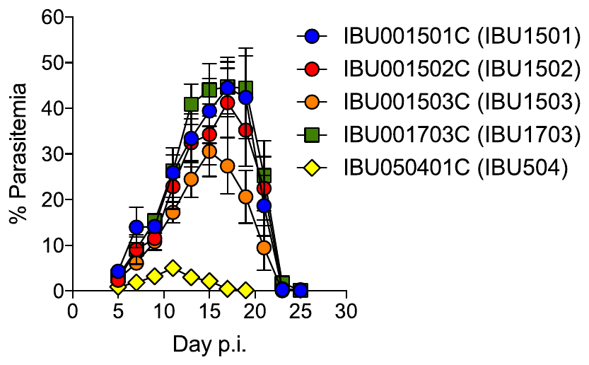

- IBU15 其實是三個房間，先前的小鼠已分不出來源。
- 同公司五個房間的感染程度也不同。

改自 [Mandal et al. 2020，Fig. 1C、pp. 2–5](https://doi.org/10.1186/s12915-020-00810-7) · [CC BY 4.0](https://creativecommons.org/licenses/by/4.0/)

## 無菌小鼠住在哪裡？

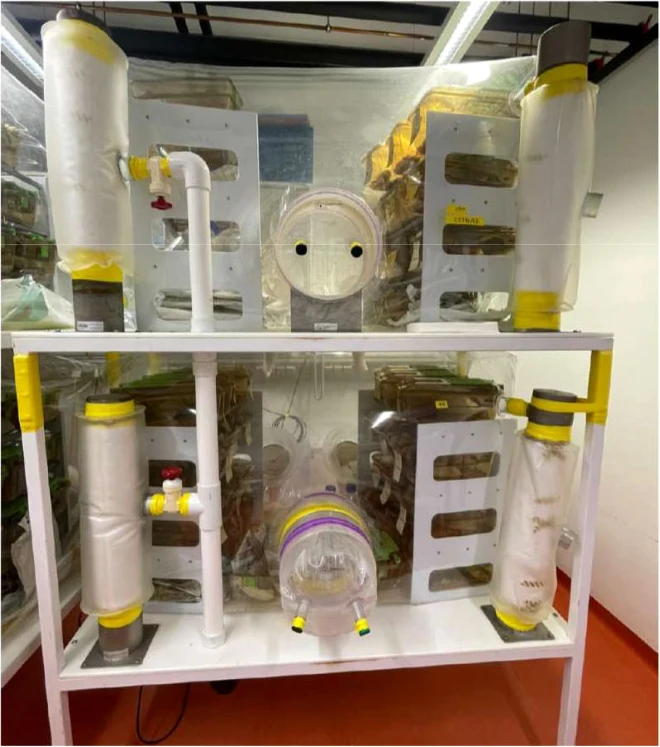

小鼠整個住在透明的塑膠罩裡

人只能戴著手套伸進去操作

空氣先過濾，東西從艙口送進去

改自 [Dremova et al. 2023，Front Immunol 14:1275109，Fig. 1B](https://doi.org/10.3389/fimmu.2023.1275109) · [CC BY 4.0](https://creativecommons.org/licenses/by/4.0/)

## 驗證：把菌相轉給無菌小鼠

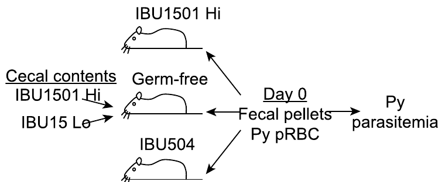

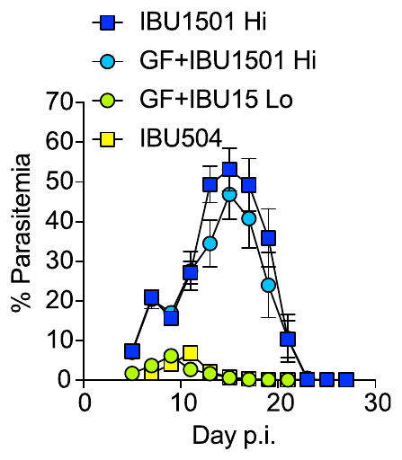

- 2016 年 8 月的菌相感染輕
- 2017 年後的菌相感染重
- 支持菌相改變的影響，但不確定是哪一種微生物。

改自 [Mandal et al. 2020，Fig. 3A、3G、pp. 5–6、9](https://doi.org/10.1186/s12915-020-00810-7) · [CC BY 4.0](https://creativecommons.org/licenses/by/4.0/) · 適應期：[Smith et al. 2018，Table 1](https://doi.org/10.1177/0023677217724823) 項目 12

## 量測高度相關，就可以直接替換嗎？

[figure not shown]

相關係數 r 描述一起變動的程度，不能單獨判定數值是否一致。

[Lazic：Chapter 5 程式與教材資料](https://github.com/stanlazic/EDLB_Rcode/blob/a1545ca6efb737c9d479f8deca084e0f77cc37c8/Ch5_Planning.R) · [Smith et al. 2018，Table 1](https://doi.org/10.1177/0023677217724823) 項目 9

## 開始前，幾種「已確認」還差什麼？

| 已有資訊 | 還不能直接保證 |
| --- | --- |
| 訂購同一供應商、生產區的動物 | 各批次的生物背景相同 |
| 原文有一週適應期 | 一週足以消除所有來源差異 |
| 新方法與參考方法高度相關 | 兩者數值一致、可以直接互換 |

先判斷哪個背景或方法差異會影響本研究，再決定需要哪些確認。

[Mandal et al. 2020，pp. 2–6、9](https://doi.org/10.1186/s12915-020-00810-7) · [Lazic：Chapter 5 程式與教材資料](https://github.com/stanlazic/EDLB_Rcode/blob/a1545ca6efb737c9d479f8deca084e0f77cc37c8/Ch5_Planning.R)

## 休息 10 分鐘

回來後：**監測、結束安排，以及開始前要做的事。**

## 研究 outcome 與 humane endpoint

[figure not shown]

具體徵象、門檻及權責，由適當專業人員依研究確認。

[Smith et al. 2018](https://doi.org/10.1177/0023677217724823)

## 監測要能觸發明確的行動

[figure not shown]

寫下觀察頻率之後，還要讓發現異常的人知道如何接續處理。

[Smith et al. 2018，Table 1](https://doi.org/10.1177/0023677217724823)，項目 3（人道終點）；圖為課堂整理

## 例子：敗血症小鼠，體溫掉到多少要處理？

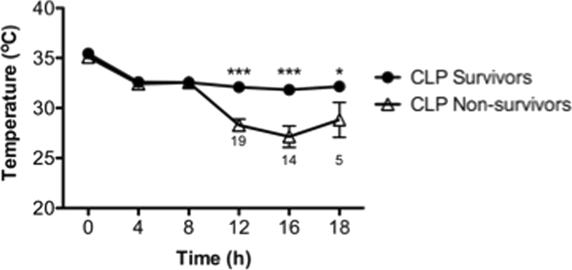

- 不等到死亡，每 4 小時量一次體溫
- 低於 30°C 或下降超過 5°C，可作為人道終點門檻

改自 [Mai et al. 2018，Intensive Care Med Exp 6:20，Fig. 1c](https://doi.org/10.1186/s40635-018-0184-3) · [CC BY 4.0](https://creativecommons.org/licenses/by/4.0/)

## 研究結束也需要事前安排

[figure not shown]

PREPARE 14–15：適用時的去向、取材與剖檢，都要事前協調。

[Smith et al. 2018](https://doi.org/10.1177/0023677217724823)

## 變更與例外：保留理由，也重看設計

[figure not shown]

- 紀錄交代發生了什麼
- 重看設計，才能判斷下一步。

# 05｜開始前：把看到的問題，變成要做的事

- 用三個問題，把今天兩個案例的問題，變成開始前要做的事。
- 最後用同樣三個問題，想一想自己的研究。

## 三個問題：把疑問變成要做的事

[figure not shown]

三個問題都要寫具體：哪一件事、哪一個角色、哪一個步驟。

三個問題為課堂整理；對應 [Smith et al. 2018，Table 1](https://doi.org/10.1177/0023677217724823) 項目 5–15

## 示範一｜Mandal：還要繼續用同一來源的小鼠

**作者原本就刻意只向同一個生產區訂小鼠，想避免菌相差異。**

| 三個問題 | 開始前的做法 |
| --- | --- |
| 先確認什麼？ | 新一批小鼠實際來自哪個房間、哪一批 |
| 找誰確認？ | 供應商；本單位接收、飼養動物的人員 |
| 確認前，先不做什麼？ | 不把新、舊批次的結果直接合併比較 |

作者在討論中建議：報告時不只寫供應商，也寫小鼠來自哪個 barrier room。

[Mandal et al. 2020，pp. 2、9](https://doi.org/10.1186/s12915-020-00810-7)；表格為課堂示範

## 示範二｜Lazic：想改用新的量測方法

**這份模擬資料，本來就是用來比較新方法和參考方法。**

| 三個問題 | 開始前的做法 |
| --- | --- |
| 先確認什麼？ | 兩種方法量同一批樣本，涵蓋本研究會用到的數值範圍；事先說好差多少可以接受 |
| 找誰確認？ | 負責量測或設備的人員；需要時找統計人員 |
| 確認前，先不做什麼？ | 不直接改用新方法做正式量測 |

差多少可以接受，沒有通用門檻，要依研究用途事先決定。

[Lazic：goldstandard 資料說明](https://github.com/stanlazic/labstats/blob/e031bddfb246bfb53d52f7a70d25cf68a88d49ed/man/goldstandard.Rd) · Bland & Altman 1986 · [Smith et al. 2018，Table 1](https://doi.org/10.1177/0023677217724823) 項目 9；表格為課堂示範

## 本週帶走：用三個問題，想自己的研究

- 來源名稱之外：實際生產背景與批次是否可追溯？
- 指標名稱之外：量測方法是否適合這次用途？
- 計畫文字之外：誰能確認現場條件，何時才能往下？

用自己的研究，寫一句：

> 我會先確認＿＿；找＿＿確認；確認之前，先不＿＿。

記一句即可，不重填期中學習單。

## Week 11｜讓讀者看得懂研究怎麼做

下週使用 **ARRIVE 2.0**：

- 哪些方法資訊已經報告？
- 哪些缺漏妨礙評估設計與結果？
- 開始前保留的紀錄，如何支撐透明報告？

## 主題索引 A｜研究形成

| 官方項目 | 課堂查閱重點 | 本週頁碼 |
| --- | --- | --- |
| 1. Literature searches | 既有證據、替代與搜尋紀錄 | 12 |
| 2. Legal issues | 適用要求、審查與責任 | 13 |
| 3. Ethical issues, harm–benefit assessment and humane endpoints | 動物使用理由與福利 | 13、32–34 |
| 4. Experimental design and statistical analysis | 問題、設計、規模與分析 | 14–15 |

「課堂查閱重點」與「本週頁碼」為教學整理。

[Smith et al. 2018，Table 1](https://doi.org/10.1177/0023677217724823) · [官方清單](https://norecopa.no/prepare)

## 主題索引 B｜研究者與設施對話

| 官方項目 | 課堂查閱重點 | 本週頁碼 |
| --- | --- | --- |
| 5. Objectives and timescale, funding and division of labour | 時程、資源與分工 | 18–19、21–24 |
| 6. Facility evaluation | 設施是否適合研究 | 20 |
| 7. Education and training | 能力與督導 | 18–19（帶到） |
| 8. Health risks, waste disposal and decontamination | 專業風險評估與必要措施 | 18–19（帶到） |

[Smith et al. 2018，Table 1](https://doi.org/10.1177/0023677217724823) · [官方清單](https://norecopa.no/prepare)

## 主題索引 C｜研究組成 9–12

| 官方項目 | 課堂查閱重點 | 本週頁碼 |
| --- | --- | --- |
| 9. Test substances and procedures | 材料與程序確認 | 29、40 |
| 10. Experimental animals | 來源與適用特徵 | 3–4、16、26–28、39 |
| 11. Quarantine and health monitoring | 與設施協調必要健康資訊 | 未細講 |
| 12. Housing and husbandry | 飼養條件與管理 | 27–28（帶到） |

[Smith et al. 2018，Table 1](https://doi.org/10.1177/0023677217724823) · [官方清單](https://norecopa.no/prepare)

## 主題索引 C｜研究組成 13–15

| 官方項目 | 課堂查閱重點 | 本週頁碼 |
| --- | --- | --- |
| 13. Experimental procedures | 程序、福利與紀錄 | 未細講 |
| 14. Humane killing, release, reuse or rehoming | 適用的研究結束安排 | 35 |
| 15. Necropsy | 適用時的終末檢查與協作 | 35 |

項目依研究調整；不適用需說明理由。

[Smith et al. 2018，Table 1](https://doi.org/10.1177/0023677217724823) · [官方清單](https://norecopa.no/prepare)

## 本週參考資料

- [Smith et al. 2018：PREPARE 原始論文](https://doi.org/10.1177/0023677217724823)
- [Norecopa：PREPARE 與官方 checklist](https://norecopa.no/prepare)
- [Smith 2020：研究規劃與品質](https://doi.org/10.1186/s42826-020-00054-0)
- [Mandal et al. 2020：動物來源、菌相與再現性](https://doi.org/10.1186/s12915-020-00810-7)
- [Ivanov et al. 2009：同一品系、不同供應商的小鼠與腸道 Th17 細胞](https://doi.org/10.1016/j.cell.2009.09.033)
- [Mai et al. 2018：用體溫預測敗血症小鼠死亡，作為人道終點](https://doi.org/10.1186/s40635-018-0184-3)
- [Dremova et al. 2023：無菌小鼠隔離器與無菌檢測](https://doi.org/10.3389/fimmu.2023.1275109)
- [Chesler et al. 2002：實驗室環境與實驗者對行為測試的影響](https://doi.org/10.1038/nn1102-1101)
- [Sorge et al. 2014：男性實驗者的氣味造成小鼠壓力與痛覺抑制](https://doi.org/10.1038/nmeth.2935)
- [Lazic：Experimental Design for Laboratory Biologists](https://stanlazic.github.io/EDLB.html)
- [labstats 資料](https://github.com/stanlazic/labstats) · EDLB_Rcode
- Bland & Altman 1986：兩種量測方法的一致性

中文概括、三個問題與示範表格為課堂整理。